| National Park Service U.S. Department of the Interior Natural Resource Stewardship and Science |  |
| --- | --- |

# Salt Marsh Elevation Monitoring at Assateague Island National Seashore: 2009 - 2024

Northeast Coastal & Barrier Network (NCBN)

January 02, 2026

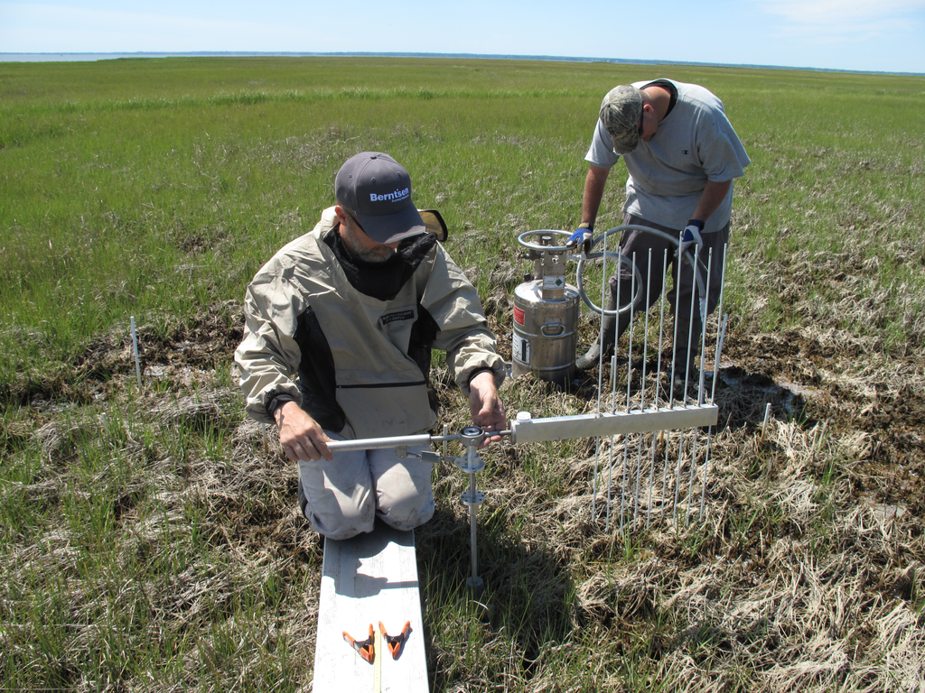

Figure 1: Surface elevation table (SET) monitoring at Assateague Island National Seashore.

# Background

Coastal wetlands exist within a narrow range of elevation which is influenced by local hydrologic conditions. As sea level rises, coastal wetland systems must build elevation at a rate equal to or greater than the rate of sea-level rise to maintain favorable hydrologic conditions for their survival (Figure 2). With global rates of sea-level rise predicted to increase over the coming decades (Church et al. 2010), many more coastal wetlands may become vulnerable to increased inundation. Additionally, certain areas of the coast, such as the mid-Atlantic region, can undergo even greater sea-level rise due to changes in coastal ocean circulation (Sallenger et al. 2012).

The Northeast Coastal & Barrier Inventory and Monitoring Network (NCBN) uses the SET technique (surface elevation table) to monitor elevation change as a vital sign of salt marsh health at Assateague Island National Seashore. The SET technique has been widely used for documenting and interpreting trends in surface elevation dynamics over time and assessing wetland vulnerability to sea-level rise (Cahoon et al. 2006, Jankowski et al. 2017, McKee 2011, Saintilan et al. 2022, Sasmito et al. 2016, Webb et al. 2013). In the following sections, we use these data to answer the following questions:

1. What are the elevation dynamics of coastal wetlands at Assateague Island National Seashore? (Figure 2B; Results Section 1)
2. How do local hydrology and tidal datums relate to marsh surface elevations? (Figure 2A and C; Results Section 2)
3. Is elevation gain sufficient to keep pace with current and predicted future sea level rise? (Figure 2D; Results Section 3)

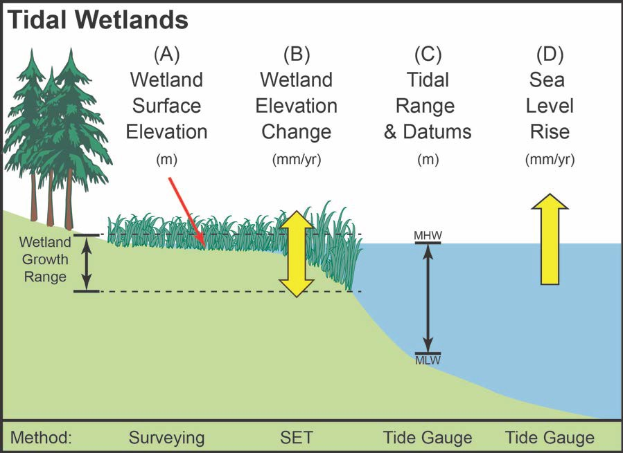

Figure 2: Conceptual diagram showing the relationship among wetland surface elevation (A), tidal datums (C), and their respective rates of change (B and D). Understanding these relationships is important for evaluating the survival of a wetland community in response to sea-level rise.

# Methods

### Protocol

NCBN’s long-term, standardized monitoring protocol for monitoring surface elevation change (Lynch et al. 2015) is implemented semiannually in the spring and fall at Assateague Island National Seashore (Figure 1). The SET is a portable mechanical leveling device providing repeated, high-resolution measurements of elevation change in wetland sediments or shallow water bottoms relative to the depth of a permanent benchmark that has been anchored into the soil until refusal. During measurements, the SET arm is attached to the permanent SET benchmark and extended over the marsh surface at four fixed positions. The SET arm is carefully leveled to rest horizontally to the ground, and each of nine fiberglass pins are lowered through the arm to the soil surface. The height of each pin above the arm is measured on repeated sampling events. Changes in the height of the pins between sampling events are used to quantify soil surface elevation change over time relative to the permanent benchmark. Note that each site has 3 stations, each station (an individual SET) has four arm positions, and each arm has nine pins - thus a total of 108 nested measurements are taken at each site on each sampling event. Additional details on the SET technique can be found in Cahoon et al. 2002a, Cahoon et al. 2002b, Cahoon 2024, Callaway et al. 2013, Lynch et al. 2015.

### Study Site & Sample Size

Surface elevation change is actively monitored at four sites within Assateague Island National Seashore (Figure 3). Sites were located so as to be both representative of the marsh habitat throughout each park and also to facilitate ease of access for repeated sampling trips (Lynch et al. 2015 - see SOP 1: Project Planning). Additional details on the status of each site, the number of replicate SET stations at each site, and the dates of the initial and most recent measurements are shown in Table 1 below.

All data utilized in this report have undergone quality assurance, quality control, and certification according to the procedures outlined in the [NPS Coastal Elevation Data QAQC and Publication SOP](https://irma.nps.gov/DataStore/Reference/Profile/2298702) (Thorsdatter et al. 2023). These data are available for public use and can be downloaded from the NPS DataStore.

Table 1. Surface elevation table sites monitored by NCBN within Assateague Island National Seashore.

| Site | SET station count | First reading | Most recent reading | Status | Dominant vegetation |
| --- | --- | --- | --- | --- | --- |
| Marsh 5 (Pope Bay) | 3 | 2009 | 2024 | active | Unvegetated with some *S. alterniflora*, *S. patens*, *D. spicata* |
| Marsh 6 (Pine Tree) | 3 | 2009 | 2024 | active | *Spartina alterniflora* |
| Marsh 8 (Valentines) | 3 | 2009 | 2024 | active | *Spartina alterniflora* |
| Marsh 11 | 3 | 2009 | 2024 | active | *Spartina alterniflora* |

### SET Data Summerization & Analysis

Prior to data analyses, the SET data were summarized using the procedures outlined in the [NPS Surface Elevation Table Protocol](https://irma.nps.gov/DataStore/Reference/Profile/2225005) (Lynch et al. 2015 - see SOP 8: SET and Marker Horizon Data Analysis). In brief, the height of each pin above the SET arm on each sampling date was first subtracted from its initial value to determine cumulative surface elevation change. Next, the pin-level cumulative surface elevation change values for each measurement date were then averaged across each of the four bearings on each SET, then the bearing-level values were averaged to the station level, and finally the station-level values were averaged to the site level. To estimate the rate of marsh surface elevation change at each site, we used a simple linear regression model where the independent variable was the time since the first measurement and the dependent variable was site-level cumulative surface elevation change as outlined in Feher et al. 2024 and Russell et al. 2022.

### Marsh Surface Elevation Data

The elevation of the marsh surface at the four marsh sites at ASIS were determined by converting SET pin measurements to NAVD88 elevations. To accomplish this, long (~24 hour) static GNSS surveys were conducted on the SET benchmarks that were installed in each of the four marshes according to the [NPS Surface Elevation Table Protocol](https://irma.nps.gov/DataStore/Reference/Profile/2225005) (Lynch et al. 2015). This resulted in the elevation of the benchmark in meters NAVD88. Accurate measures of the SET benchmark allowed for the conversion of SET pin data from the most recent sampling event to an NAVD88 elevation using the formula outlined in the [NPS Surface Elevation Table Protocol](https://irma.nps.gov/DataStore/Reference/Profile/2225005) (Lynch et al. 2015 - see SOP 6: Surveying the SET Mark):

$$MSE = A + B - (D-C)$$

where MSE is the marsh surface elevation in meters NAVD88, A is the NAVD88 elevation of the SET benchmark, B is the vertical offset of the SET instrument above the marsh, C is the SET pin measurement, and D is the length of the pin.

### Hydrologic Data, Tidal Datums, & Marsh Flooding

Water level data were collected at continuous 15 minute intervals from 3 permanent water level loggers (HOBO® 13-Foot Water Level Data Logger, model U20-001-04) installed in the nearest creek/ditch at Marsh 5 (Pope Bay), Marsh 6 (Pine Tree), and Marsh 8 (Valentines) as outlined in the [NCBN Water Level Data Collection and Management](https://irma.nps.gov/DataStore/Reference/Profile/2237862) methods document (Curdts 2017). Note that the data from the water logger at Marsh 6 was also applied to Marsh 11 given their close proximity. Prior to the calculation of marsh flooding time and tidal datums, the raw water level data were first converted to meters NAVD88 using the absolute elevation of the water loggers derived from on-the-ground RTK surveys as outlined in the [NPS Surface Elevation Table Protocol](https://irma.nps.gov/DataStore/Reference/Profile/2225005) (Lynch et al. 2015 - see SOP 6: Surveying the SET Mark). Both the raw water level data and water level data relative to NAVD88 (North American Vertical Datum of 1988) were then uploaded to the NPS AQUARIUS WebPortal for QAQC, certification, and storage. In order to calculate the percentage of time that each marsh was flooded, the water level data referenced to NAVD88 were compared to the NAVD88 ground elevations of the marsh at each site (Curdts 2017). Similarly, we also used the water level data referenced to NAVD88 to calculate site-level tidal datums for mean high water (MHW), mean low water (MLW), and mean sea level (MSL) as defined by NOAA ([NOAA Tides and Currents Glossary](https://tidesandcurrents.noaa.gov/publications/glossary2.pdf)).

### Elevation Capital

We calculated the normalized elevation capital (NEC), a metric of marsh vulnerability to sea-level rise, using the formula defined by Morris et al. 2020:

$$NEC=\frac{MSE - (MSL - 0.1)}{MHW + 0.3 - (MSL - 0.1)}$$

where MSE is the marsh surface elevation, MSL is mean sea level, MHW is mean high water, and 0.1 m below mean sea level to 0.3 m above mean high water represent the assumed growth range of *Spartina alterniflora* (the dominant vegetation type in salt marshes of the northeastern U.S.). NEC ranges between 0 to 1 and marshes with an NEC below 0.5 are considered vulnerable to sea-level rise or unstable, whereas marshes with an NEC above 0.5 are considered more stable with higher elevations (Roman et al. 2024).

### Sea-Level Data & Rates of Sea-Level Rise

#### Recent SLR

We estimated a recent rate of relative sea-level rise using the method described in Moon et al. 2022, where a linear regression model was applied to the monthly mean sea-level data with the average seasonal cycle removed by subsetting the data from the Ocean City, MD gauge for the most recent tidal epoch between 2001 to 2019.

#### Future SLR

We estimated future projected relative sea-level rise rates using the five alternative SLR scenarios produced by Sweet et al. 2022 for the 5th National Climate Assessment. The low, intermediate-low, intermediate, intermediate-high, and high SLR scenarios correspond to global mean sea level increases of 0.3 m, 0.5 m, 1.0 m, 1.5 m, and 2.0 m (respectively) by 2100. To approximate the RSLR rate by 2100 under each of the five scenarios, we used the data provided by Sweet et al. (2022) to estimate future RSLR rates for the 2090-2100 decade for the Ocean City, MD tide gauge as outlined in Chivoiu et al. 2020, Moon et al. 2022, and Osland et al. 2024.

[interactive chart not shown]

Figure 3: Individual SET stations within Assateague Island National Seashore. Click on the points to see the site and station labels.

# Results

### 1. What are the elevation dynamics of coastal wetlands at Assateague Island National Seashore?

Across all four actively monitored sites at Assateague Island National Seashore, the park-wide average rate of surface elevation change was **3.62 ± 0.83 mm/yr**. Site-level rates of surface elevation change varied from a low of 2.02 ± 0.11 mm/yr at Marsh 11 to a high of 5.04 ± 0.14 mm/yr and 5.04 ± 0.21 mm/yr at Marsh 6 (Pine Tree) and Marsh 8 (Valentines) (Table 2; Figure 4).

Table 2. Site-level rates of surface elevation change within Assateague Island National Seashore. Rates of surface elevation change labeled with * are significantly different from 0. Note that 𝑟² values represent the proportion of variation in the data explained by the site-level rates of surface elevation change.

| Site | Rate of surface elevation change (mm/yr) | Adjusted 𝑟² | Years measured |
| --- | --- | --- | --- |
| Marsh 5 (Pope Bay) | 2.36 ± 0.25* | 0.78 | 2009-2024 |
| Marsh 6 (Pine Tree) | 5.04 ± 0.14* | 0.98 | 2009-2024 |
| Marsh 8 (Valentines) | 5.04 ± 0.21* | 0.96 | 2009-2024 |
| Marsh 11 | 2.02 ± 0.11* | 0.93 | 2009-2024 |

[interactive chart not shown]

Figure 4: Site-level surface elevation change at Assateague Island National Seashore. Rates of surface elevation change (SEC) are shown in panel labels. Hover the mouse over a data point to see the cumulative surface elevation change value on a specific date, or click and drag over a specific time to zoom in. Double click to zoom back out.

### 2. How do local hydrology and tidal datums relate to marsh surface elevations?

#### Local Hydrology & Tidal Datums

Water level data was collected in nearby tidal creeks at Marsh 5 (Pope Bay), Marsh 6 (Pine Tree), and Marsh 8 (Valentines) over the period between 2012 - 2024 and is presented in Figure 5 below. Note that the data from the water logger at Marsh 6 was also applied to Marsh 11 given their close proximity. Mean low water (MLW) at the four sites varied by 0.036 m, with Marsh 8 (Valentines) having the lowest MLW value (-0.075 m NAVD88) and Marsh 5 (Pope Bay) having the highest MLW value (-0.039 m NAVD88). Similarly, mean high water (MHW) varied by 0.039 m, with Marsh 8 (Valentines) having the lowest MHW value (0.120 m NAVD88) and Marsh 5 (Pope Bay) having the highest MHW value (0.159 m). Finally, mean sea level varied by 0.039 m, with Marsh 8 (Valentines) having the lowest MSL value (0.020 m NAVD88) and Marsh 5 (Pope Bay) having the highest MSL value (0.060 m NAVD88). The park-wide average values for MLW, MHW, and MSL were -0.055, 0.145, and 0.043 m NAVD88, respectively.

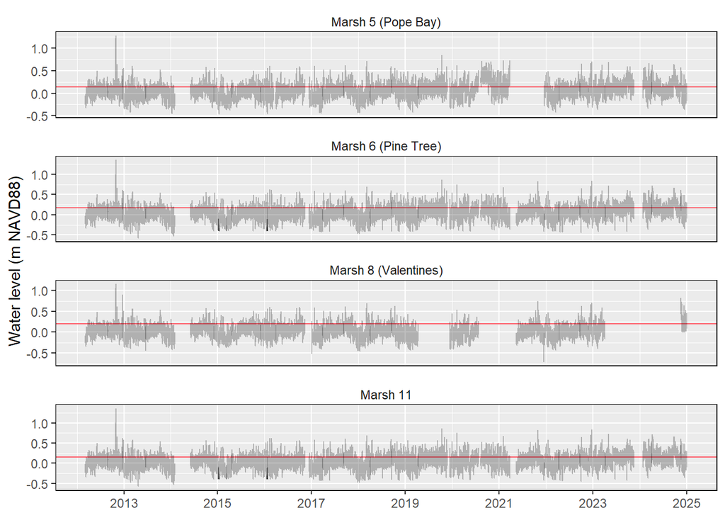

Figure 5: Site-level water level data at Assateague Island National Seashore. Note that the red line indicates the marsh surface elevation (m NAVD88).

#### Marsh Elevation, Flooding, & Elevation Capital

Marsh surface elevation at Assateague Island National Seashore varied by 0.054 m, with Marsh 5 (Pope Bay) having the lowest elevation (0.143 m NAVD88) and Marsh 8 (Valentines) having the highest elevation (0.197 m NAVD88). The park-wide average marsh surface elevation was 0.166 m NAVD88. Accordingly, the percentage of time that the marsh was flooded ranged from a low of 11% at Marsh 8 (Valentines) to a high of 28% at Marsh 5 (Pope Bay) (park-wide average: 21%). Elevation capital ranged from a low of 0.37 at Marsh 5 (Pope Bay) to a high of 0.55 at Marsh 8 (Valentines). Out of the four sites at Assateague Island National Seashore, three sites - Marsh 5 (Pope Bay), Marsh 6 (Pine Tree), and Marsh 11 - had elevation capital values below 0.5, indicating a higher vulnerability to sea-level rise. Marsh 8 (Valentines) had an elevation capital value above 0.5, indicating a lower vulnerability to sea-level rise. Figure 6 below illustrates the relationship between marsh surface elevation, local tidal datums, flooding, and elevation capital.

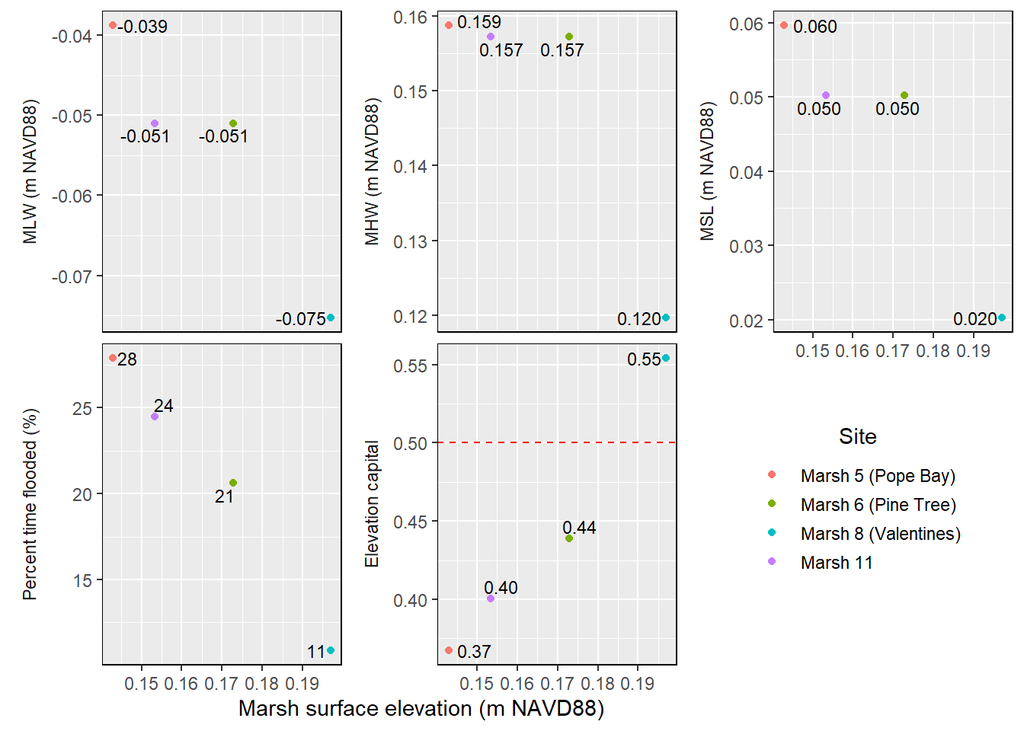

### 3. Is elevation gain sufficient to keep pace with current and predicted future sea-level rise?

#### Comparisons to current sea-level rise

As of January 2026, the current long-term rate of relative sea-level rise from the nearest NOAA tide gauge at Ocean City, MD was 5.28 mm/yr (± 0.35) for the period between 1975 to 2024 (https://tidesandcurrents.noaa.gov/sltrends/sltrends_station.shtml?id=8570283). Out of the four site(s) at Assateague Island National Seashore, two site(s) - Marsh 6 (Pine Tree) and Marsh 8 (Valentines) - gained elevation at a rate close to or greater than the relative long-term rate of sea-level rise (Figure 7).

Additionally, using the sea-level data from the nearby NOAA tide gauge, we calculated a recent rate of relative sea-level rise of 7.26 mm/yr (± 1.16) for Assateague Island National Seashore over the most recent tidal epoch (2001-2019). None of the sites at Assateague Island National Seashore gained elevation at a rate close to or greater than the relative recent rate of sea-level rise (Figure 7).

[interactive chart not shown]

Figure 7: Site-level surface elevation change at Assateague Island National Seashore compared to relative long-term and recent rates of sea-level rise. Hover the mouse over a data point to see the rate of surface elevation change or sea-level rise, or click and drag over a specific area to zoom in. Double click to zoom back out.

#### Comparisons to future sea-level rise

Based on the calculations provided in Sweet et al. 2022, future predicted rates of relative sea-level rise by 2100 for Assateague Island National Seashore were 6, 9, 22, 29, and 38 mm/yr for the low, intermediate-low, intermediate, intermediate-high, and high future sea-level rise scenarios, respectively. Notably, none of the sites gained elevation at a rate close to or greater than the future predicted low, intermediate-low, intermediate, intermediate-high, or high rates of sea-level rise (Figure 8).

[interactive chart not shown]

Figure 8: Site-level surface elevation change at Assateague Island National Seashore compared to future predicted rates of sea-level rise. Hover the mouse over a data point to see the rate of surface elevation change or future predicted sea-level rise, or click and drag over a specific area to zoom in. Double click to zoom back out.

# Discussion & Conclusions

Figure 9 below visually summarizes the relationships between elevation change, marsh surface elevation, local tidal datums, and long-term and recent rates of sea-level rise. Marsh 8 (Valentines) has the highest surface elevation and thus has the highest elevation capital of the four sites. Marsh 6 (Pine Tree) has the second highest surface elevation although elevation capital at this site was below the 0.5 threshold for vulnerability to sea-level rise. Both Marsh 8 (Valentines) and Marsh 6 (Pine Tree) have surface elevations well above the local Mean High Water datum (MHW) and rates of surface elevation change similar to the long-term rate of sea-level rise. Marsh 5 (Pope Bay) and Marsh 11 have lower surface elevations and thus have lower elevation capital. Both Marsh 5 (Pope Bay) and Marsh 11 have surface elevations near the local Mean High Water datum (MHW) and lower rates of surface elevation change that are well below both the long-term and recent rates of sea-level rise.

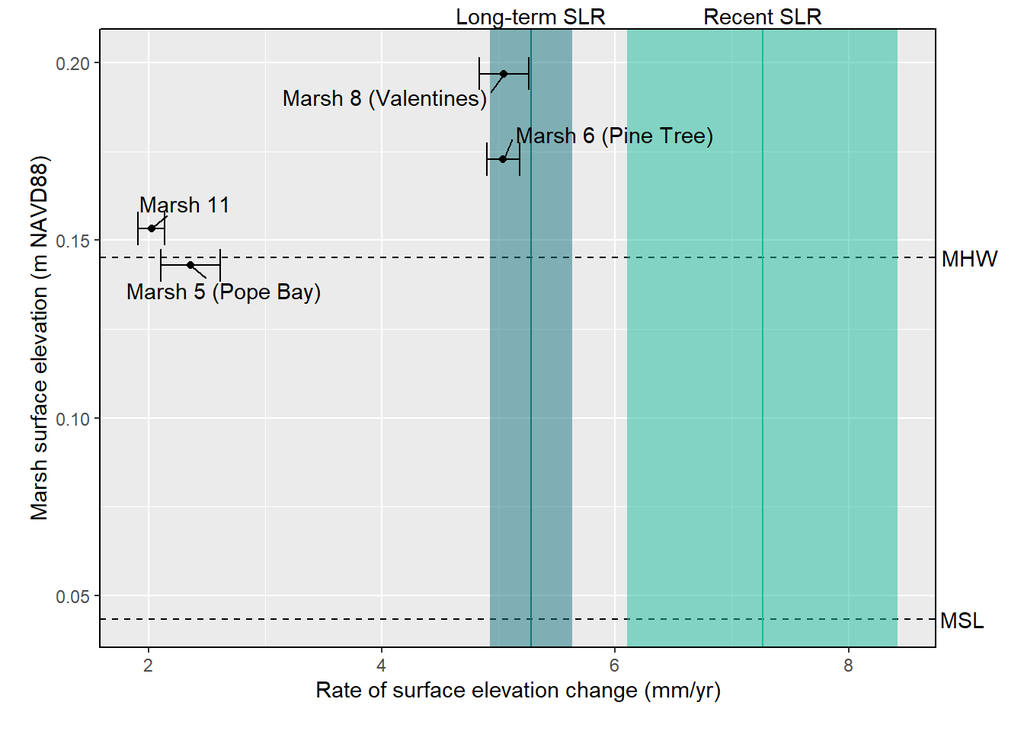

Figure 9: Surface elevation change rates and site elevations at Assateague Island National Seashore compared to local tidal datums and rates of SLR. Note that the dashed horizontal lines represent park-wide average Mean High Water (MHW) and Mean Sea Level (MSL).

A summary of these results can be seen in Table 3 below. Two of these sites - Marsh 8 (Valentines) and Marsh 6 (Pine Tree) - are keeping pace with the local long-term rate of sea-level rise but are unlikely to be able to keep pace with the higher recent rate of sea-level rise. Conversely, the other two sites - Marsh 5 (Pope Bay) and Marsh 11 - not keeping pace with either the local long-term or recent rates of sea-level rise. Notably, Marsh 5 (Pope Bay) appears to have the most potential issues affecting its long-term resilience - it has a relatively low rate of surface elevation change and low marsh surface elevation and is flooded over 25% of the time. One caveat for these results is the rates of surface elevation change and marsh surface elevations at these sites are only representative of the very small area that is being measured and thus may not necessarily be representative of changes in the park as a whole. The survival of these marshes is linked to their ability to maintain a favorable vertical position in relation to the local hydrologic conditions. As rates of sea level rise and hydrology, sediment input, nutrients, and other conditions in the park change, the marshes must adapt. If they cannot, their survival in the future would be uncertain. The NPS is continuing to monitor these vulnerable ecosystems.

Table 3. Assateague Island National Seashore data summary (2009 - 2024).

| Site | SEC rate (mm/yr) | Marsh elevation (m NAVD88) | MHW (m NAVD88) | MSL (m NAVD88) | Time flooded (%) | Elevation capital | SEC vs. SLR-long<sup>1</sup> | SEC vs. SLR-recent<sup>2</sup> |
| --- | --- | --- | --- | --- | --- | --- | --- | --- |
| Marsh 5 (Pope Bay) | 2.36 ± 0.25 | 0.143 | 0.159 | 0.060 | 28 | 0.37 | lower | lower |
| Marsh 6 (Pine Tree) | 5.04 ± 0.14 | 0.173 | 0.157 | 0.050 | 21 | 0.44 | close or greater | lower |
| Marsh 8 (Valentines) | 5.04 ± 0.21 | 0.197 | 0.120 | 0.020 | 11 | 0.55 | close or greater | lower |
| Marsh 11 | 2.02 ± 0.11 | 0.153 | 0.157 | 0.050 | 24 | 0.40 | lower | lower |

<sup>1</sup> Long-term SLR - rate of surface elevation change compared to the long-term rate of SLR from the NOAA gauge at Ocean City, MD (1975-2024).  
<sup>2</sup> Recent SLR - rate of surface elevation change compared to the recent rate of SLR from the NOAA gauge at Ocean City, MD (2001-2019).

# References

[Cahoon, D.R., Lynch, J.C., Hensel, P., Boumans, R., Perez, B.C., Segura, B., and Day Jr, J.W., 2002. High-precision measurements of wetland sediment elevation: I. Recent improvements to the sedimentation-erosion table. Journal of Sedimentary Research 72:730-733.](https://doi.org/10.1306/020702720730)  
[Cahoon, D.R., Lynch, J.C., Perez, B.C., Segura, B., Holland, R.D., Stelly, C., Stephenson, G., and Hensel, P., 2002. High-precision measurements of wetland sediment elevation: II. The rod surface elevation table. Journal of Sedimentary Research 72:734-739.](https://doi.org/10.1306/020702720734)  
[Cahoon, D.R., Hensel, P.F., Spencer, T., Reed, D.J., McKee, K.L., and Saintilan, N., 2006. Coastal wetland vulnerability to relative sea-level rise: Wetland elevation trends and process controls. In *Wetlands and Natural Resource Management*, ed. J.T.A. Verhoeven, B. Beltman, R. Bobbink, and D.F. Whigham, 271–292. Berlin: Springer.](https://doi.org/10.1007/978-3-540-33187-2_12)  
[Cahoon, D.R., Lynch, J.C., Roman, C.T., Schmidt, J.P., and Skidds, D.E., 2019. Evaluating the relationship among wetland vertical development, elevation capital, sea-level rise, tidal marsh sustainability. Estuaries and Coasts 42:1-15.](https://doi.org/10.1007/s12237-018-0448-x)  
[Callaway, J.C., Cahoon, D.R., and Lynch, J.C., 2013. The surface elevation table-marker horizon method for measuring wetland accretion and elevation dynamics. In *Methods in Biogeochemistry of Wetlands*, ed. R.D. DeLaune, K. Reddy, C. Richardson, and J.P. Megonigal, 901–917. Madison, WI: Soil Science Society of America.](https://doi.org/10.2136/sssabookser10.c46)  
[Chivoiu, B., Osland, M.J., Collini, R., Martin, S., Tirpak, J., and Wilson, B., 2020. Local sea level rise information sheets for Texas, Louisiana, Mississippi, Alabama and Florida: Northern Gulf of Mexico Sentinel Site Cooperative, U.S. Geological Survey and U.S. Fish and Wildlife Service: Mississippi-Alabama Sea Grant Consortium, https://placeslr.org/our-products/federally-managed-lands-two-pagers/.](https://placeslr.org/our-products/federally-managed-lands-two-pagers/)  
[Church, J.A, Woodworth, P.L., Aarup, T., and Wilson, W.S., 2010. Understanding sea level rise and variability. Blackwell, New York, NY.](https://doi.org/10.1002/9781444323276)  
[Curdts, L.T., 2017. Continuous water level data collection and management using Onset HOBO® data loggers: A Northeast Coastal and Barrier Network methods document. Natural Resource Report. NPS/NCBN/NRR—2017/1370. National Park Service. Fort Collins, Colorado https://irma.nps.gov/DataStore/Reference/Profile/2237862.](https://irma.nps.gov/DataStore/Reference/Profile/2237862)  
[Feher, L.C., Osland, M.J., Johnson, D.J., Grace, J.B., Guntenspergen, G.R., Stewart, D.R., Coronado-Molina, C., and Sklar, F.H., 2024. Nonlinear patterns of surface elevation change in coastal wetlands: The value of generalized additive models for quantifying rates of change. Estuaries and Coasts 47:1893-1902.](https://doi.org/10.1007/s12237-023-01268-w)  
[Jankowski, K.L., Törnqvist, T.E., and Fernandes, A.M., 2017. Vulnerability of Louisiana’s coastal wetlands to present-day rates of relative sea-level rise. Nature Communications 8:1–7.](https://doi.org/10.1038/ncomms14792)  
[Lynch, J.C., Hensel, P., and Cahoon, D.R., 2015. The surface elevation table and marker horizon technique: A protocol for monitoring wetland elevation dynamics. Natural Resource Report NPS/NCBN/NRR—2015/1078. National Park Service, Fort Collins, Colorado.](https://irma.nps.gov/DataStore/Reference/Profile/2225005)  
[Lynch, J.C., Winn, N., Kovalenko, K., and Guntenspergen, G., 2024. Comparing wetland elevation change using a surface elevation table, digital level, and total station. Estuaries and Coasts 47:2071-2079.](https://doi.org/10.1007/s12237-023-01263-1)  
[McKee, K.L., 2011. Biophysical controls on accretion and elevation change in Caribbean mangrove ecosystems. Estuarine, Coastal and Shelf Science 91:475–483.](https://doi.org/10.1016/j.ecss.2010.05.001)  
[Moon, J.A., Feher, L.C., Lane, T.C., Vervaeke, W.C., Osland, M.J., Head, D.M., Chivoiu, B.C., Stewart, D.R., Johnson, D.J., Grace, J.B., and Metzger, K.L., 2022. Surface elevation change dynamics in coastal marshes along the Northwestern Gulf of Mexico: Anticipating effects of rising sea-level and intensifying hurricanes. Wetlands 42(5):49.](https://doi.org/10.1007/s13157-022-01565-3)  
Morris, J.T., Sundareshwar, P.V., Nietch, C.T., Kjerve, B., and Cahoon, D.R., 2002. Responses of coastal wetlands to rising sea level. Ecology 83:2869-2877.  
[Morris, J.T., Lynch, J., Renken, K.A., Stevens, S., Tyrrell, M., and Plaisted, H., 2020. Tidal and hurricane impacts on saltmarshes in the northeastern coastal and barrier network: Theory and empirical results. Estuaries and Coasts 43:1658-1671.](https://doi.org/10.1007/s12237-020-00790-5)  
[Osland, M.J., Chivoiu, B., Grace, J.B., Enwright, N.M., Guntenspergen, G.R., Buffington, K.J., Thorne, K.M., Carr, J.A., Sweet, W.V., and Couvillion, B.R., 2024. Rising seas could cross thresholds for initiating coastal wetland drowning within decades across much of the United States. Communications Earth & Environment 5(1):372.](https://doi.org/10.1038/s43247-024-01537-x)  
[Roman, C.T., Lynch, J.C., and Cahoon, D.R., 2024. Twenty-year record of salt marsh elevation dynamics in response to sea-level rise and storm-driven barrier island geomorphic processes: Fire Island, NY, USA. Estuaries and Coasts:1903-1917.](https://doi.org/10.1007/s12237-023-01234-6)  
[Rooth J.E., and Stevenson, J.C., 2000. Sediment deposition patterns in Phragmites australis communities: Implications for coastal areas threatened by rising sea-level. Wetlands Ecology and Management 8:173-183.](https://doi.org/10.1023/A:1008444502859)  
[Russell, B. T., Cressman, K. A., Schmit, J. P., Shull, S., Rybczyk, J. M., and Frost, D. L., 2022. How should surface elevation table data be analyzed? A comparison of several commonly used analysis methods and one newly proposed approach. Environmental and Ecological Statistics 29:359-391.](https://doi.org/10.1007/s10651-021-00524-1)  
[Saintilan, N., Kovalenko, K.E., Guntenspergen, G., Rogers, K., Lynch, J.C., Cahoon, D.R., Lovelock, C.E., Friess, D.A., Ashe, E., Krauss, K.W., Cormier, N., Spencer, T., Adams, J., Raw, J., Ibanez, C., Scarton, F., Temmerman, S., Meire, P., Maris, T., Thorne, K., Brazner, J., Chmura, G.L., Bowron, T., Gamage, V.P., Cressman, K., Endris, C., Marconi, C., Marcum, P., St. Laurent, K., Laurent, W., Reay, K.B., Garwood, J.A., Raposa, K.B., and Khan, N., 2022. Constraints on the adjustment of tidal marshes to accelerating sea level rise. Science 377:523–527.](https://doi.org/10.1126/science.abo7872)  
[Sallenger, A., Doran, K., and Howd, P., 2012. Hotspot of accelerated sea-level rise on the Atlantic coast of North America. Nature Climate Change 2:884–888.](https://doi.org/10.1038/nclimate1597)  
[Sasmito, S.D., Murdiyarso, D., Friess, D.A., and Kurnianto, S., 2016. Can mangroves keep pace with contemporary sea level rise? A global data review. Wetlands Ecology and Management 24:263–278.](https://doi.org/10.1007/s11273-015-9466-7)  
[Sweet, W.V., Hamlington, B.D., Kopp, R.E., Weaver, C.P., Barnard, P.L., Bekaert, D., Brooks, W., Craghan, M., Dusek, G., Frederikse, T., Garner, G., Genz, A.S., Krasting, J.P., Larour, E., Marcy, D., Marra, J.J., Obeysekera, J., Osler, M., Pendleton, M., Roman, D., Schmied, L., Veatch, W., White, K.D., and Zuzak, C., 2022. Global and Regional Sea Level Rise Scenarios for the United States: Updated Mean Projections and Extreme Water Level Probabilities Along U.S. Coastlines. NOAA Technical Report NOS 01. National Oceanic and Atmospheric Administration, National Ocean Service, Silver Spring, MD, 111 pp.](https://oceanservice.noaa.gov/hazards/sealevelrise/noaa-nos-techrpt01-global-regional-SLR-scenarios-US.pdf)  
[Thorsdatter, W., Skidds, D.N., Cheng, E., and Kozlowski, A., 2023. Standard Operating Procedure 2.3.05 Monitoring Coastal Wetland Elevation Data QAQC and Data Publication—Version 1.0. Northeast Temperate Network (NETN), the Northeast Coastal and Barrier Network (NCBN), the National Capital Region Network (NCRN), the Southeast Coast Network (SECN), and the South Florida/Caribbean Network (SFCN). https://irma.nps.gov/DataStore/Reference/Profile/2298702](https://irma.nps.gov/DataStore/Reference/Profile/2298702)  
[Vincent, R.E., Burdick, D.M., and Dionne, M., 2013. Ditching and ditch-plugging in New England salt marshes: Effects on hydrology, elevation, and soil characteristics. Estuaries and Coasts 36:610-625.](https://doi.org/10.1007/s12237-012-9583-y)  
[Webb, E.L., Friess, D.A., Krauss, K.W., Cahoon, D.R., Guntenspergen, G.R., and Phelps, J., 2013. A global standard for monitoring coastal wetland vulnerability to accelerated sea-level rise. Nature Climate Change 3:458-465.](https://doi.org/10.1038/nclimate1756)  
[Whelan K.R.T., Smith, T.J., Anderson, G.H., and Ouellette, M.L., 2009. Hurricane Wilma’s impact on overall soil elevation and zones within the soil profile in a mangrove forest. Wetlands 29:16-23.](https://doi.org/10.1672/08-125.1)  
[Wigand, C., Roman, C.T., Davey, E., Stolt, M., Johnson, R., Hanson, A., Watson, E.B., Moran, S.B., Cahoon, D.R., Lynch, J.C., and Rafferty, P., 2014. Below the disappearing marshes of an urban estuary: historic nitrogen trends and soil structure. Ecological Applications 24:633-649.](https://doi.org/10.1890/13-0594.1)

## Contact Information

Katie Button, NCBN Biologist & SET Protocol Lead  
Kaitlyn_Button@nps.gov  
Laura Feher, NCBN Biologist & Data Scientist  
Laura_Feher@nps.gov  
[Vital Signs: Northeastern Coastal & Barrier Inventory and Monitoring Network](https://www.nps.gov/im/ncbn/what-we-monitor.htm)  
[Reports & Publications (U.S. National Park Service) (nps.gov)](https://www.nps.gov/im/ncbn/reports-publications-data.htm)